# In Course Exercise 2

Brooke Anderson

January 12, 2016

## Designing a plot

For today’s exercise, you’ll be building a plot using the `worldcup` data from the `faraway` package. First, load in that data.

Next, say you want to look at the relationship between the number of minutes that a player played in the 2010 World Cup (`Time`) and the number of shots the player took on goal (`Shots`). On a sheet of paper, and talking with your partner, decide how the two of you would design a plot to explore and present this relationship. How would you incorporate some of the principles of creating good graphs?

### Example R code

```r
library(faraway)
data(worldcup)
```

## Basic scatterplot with ggplot

Perform the following tasks:

- Install and load the `ggplot2` package.
- For the `worldcup` data, plot a scatterplot of Time (on the x-axis) versus Shots using ggplot

### Example R code

Install and load the `ggplot2` package:

```r
# install.packages("ggplot2")
library(ggplot2)
```

Create a plot of the relationship using ggplot:

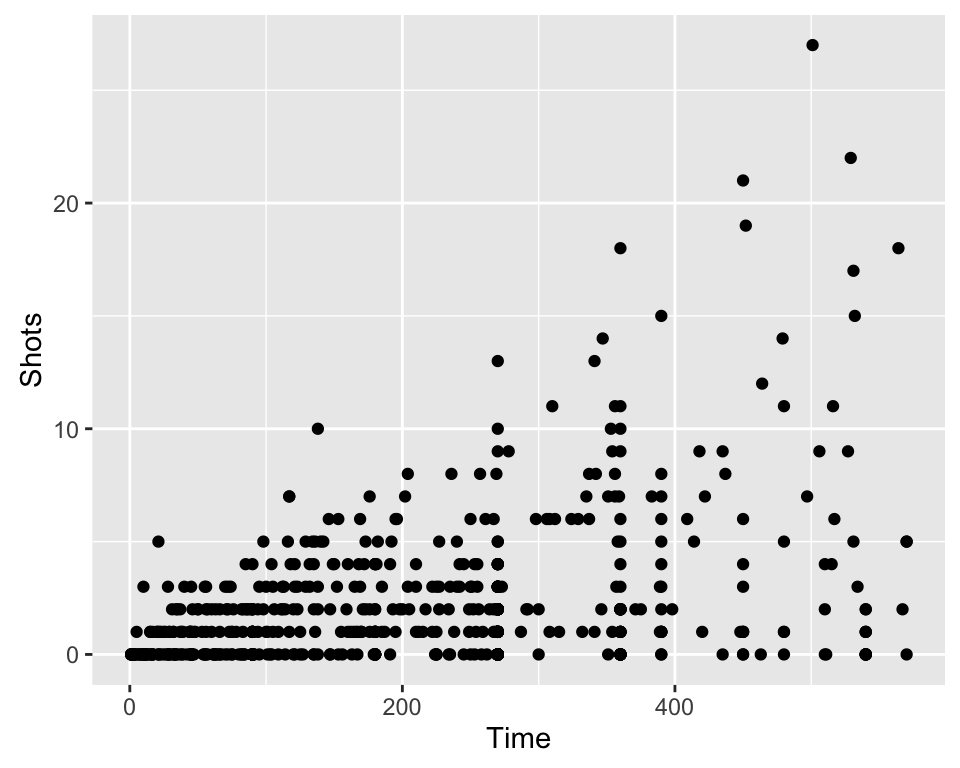

```r
ggplot(worldcup, aes(x = Time, y = Shots)) +
        geom_point()
```

### Fancier graphs with ggplot

In this section, we’ll work on creating a plot like this:

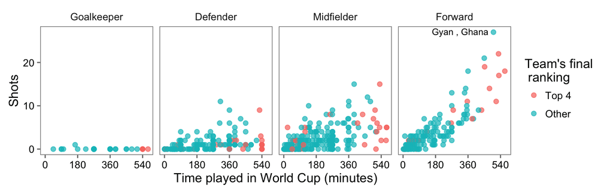

Try the following tasks:

- First, before you start coding, talk with your partner about how this graph is different from the simple one you created with `ggplot` in the last section. Also discuss what you can figure out from this new graph that was less clear from the simpler one.
- Use the `xlab()` function to make a clearer title for the x-axis.
- Often, in graphs with a lot of points, it’s hard to see some of the points, because they overlap other points. Three strategies to address this are: (a) make the points smaller; (b) make the points somewhat transparent; and (c) jitter the points. Try doing the first two with the simple ggplot scatterplot you created in the previous section of Shots by Time.
- Create a new column in the `worldcup` data called `top_four` that specifies whether or not the `Team` for that observation was one of the top four teams in the tournament (Netherlands, Uruguay, Spain, and Germany). Make the colors of the points correspond to whether the team was a top-four team.
- Create small multiples: This relationship is probably different by position. Use faceting to create different graphs for each position.
- Make order count: What order are the faceted graphs currently in? Offensive players have more chances to take shots than defensive players, so that might be a useful ordering for the facets. Re-order the `Position` factor column to go from nearest your own goal to nearest the opponents goal, and then re-plot the graph from the previous step.
- Highlighting interesting data: Who had the most shots in the 2010 World Cup? Was he on a top-four team? Use `geom_text()` to label his point on the graph with his name.
- Increase data density: Try changing the theme, to come up with a graph with a bit less non-data ink. From the `ggthemes` package (you’ll need to install it if you don’t already have it), try some of the following themes: `theme_few()`, `theme_tufte()`, `theme_stata()`, `theme_fivethirtyeight()`, `theme_economist_white()`, `theme_wsj()`.

### Example R code

As a reminder, here’s the code to do a simple scatterplot ot Shots by Time for the `worldcup` data:

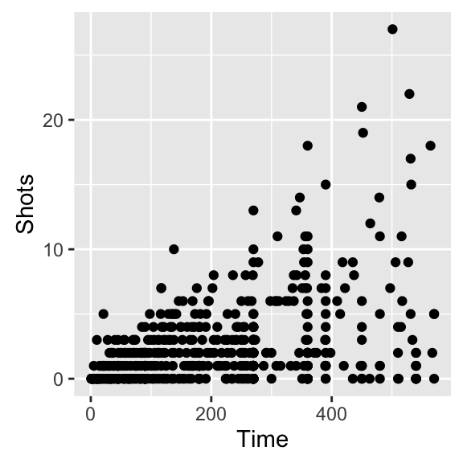

```r
ggplot(worldcup, aes(x = Time, y = Shots)) +
        geom_point()
```

To add a clearer x-axis label that the current one, use `xlab()`:

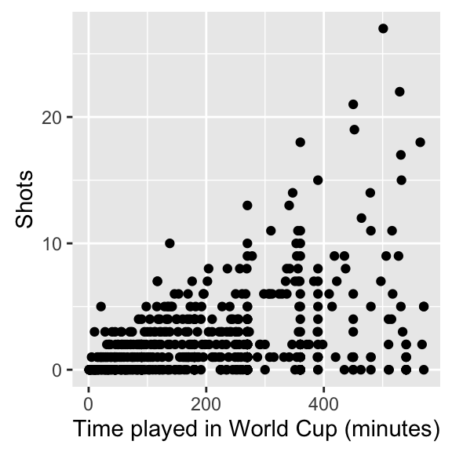

```r
ggplot(worldcup, aes(x = Time, y = Shots)) +
        geom_point() +
        xlab("Time played in World Cup (minutes)")
```

To make the points smaller, use the `size` option in `geom_point()` (smaller than about 2 = smaller than default, larger than about 2 = larger than default):

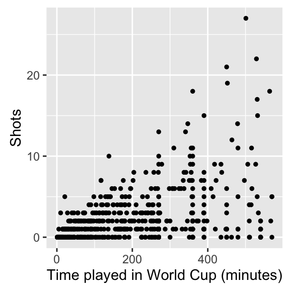

```r
ggplot(worldcup, aes(x = Time, y = Shots)) +
        geom_point(size = 1)  +
        xlab("Time played in World Cup (minutes)")
```

To make the points semi-transparent, use the `alpha` option in `geom_point()` (closer to 0 = more tranparent, closer to 1 = more opaque):

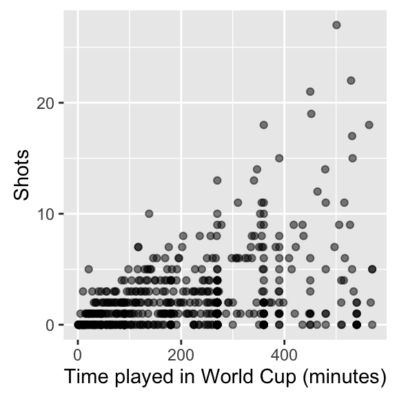

```r
ggplot(worldcup, aes(x = Time, y = Shots)) +
        geom_point(alpha = 0.5)  +
        xlab("Time played in World Cup (minutes)")
```

To jitter the points some, use the `position = "jitter"` option in `geom_point()`:

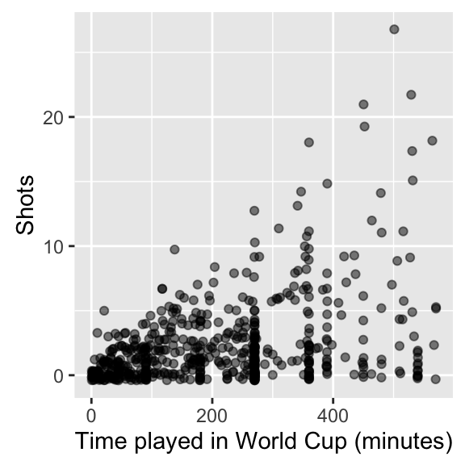

```r
ggplot(worldcup, aes(x = Time, y = Shots)) +
        geom_point(size = 1.5, position = "jitter",
                   alpha = 0.5)  +
        xlab("Time played in World Cup (minutes)")
```

To create a new, `top_four` column, first create vector that lists those top four teams, then create a logical vector in the dataframe for whether the team for that observation is in one of the top four teams:

```r
top_four <- c("Spain", "Germany",
              "Uruguay", "Netherlands")
worldcup$top_four <- worldcup$Team %in% top_four
summary(worldcup$top_four)
```

```
##    Mode   FALSE    TRUE    NA's
## logical     517      78       0
```

To color points by this variable, use `color =` in the `aes()` part of the `ggplot()` call:

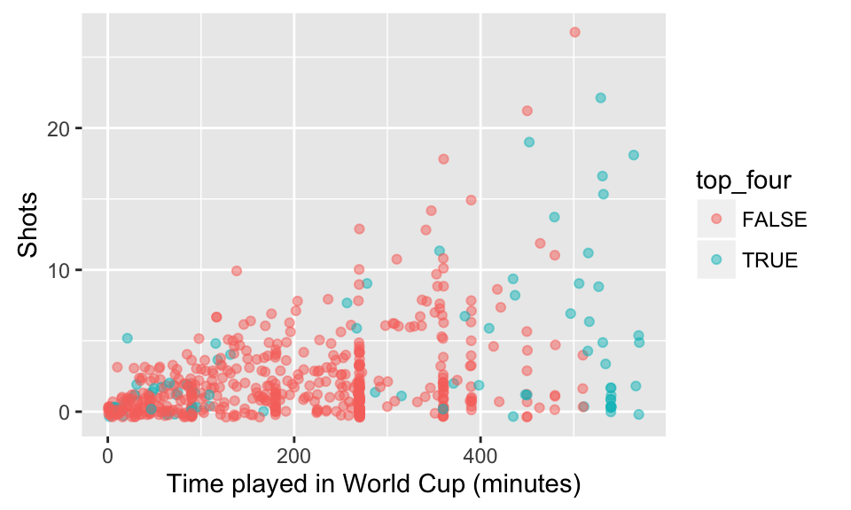

```r
ggplot(worldcup, aes(x = Time, y = Shots,
                     color = top_four)) +
        geom_point(size = 1.5, position = "jitter",
                   alpha = 0.5)  +
        xlab("Time played in World Cup (minutes)")
```

To make R label this more nicely, convert the `top_four` column into the factor class, with the labels you want to use in the figure legend:

```r
worldcup$top_four <- factor(worldcup$Team %in% top_four,
                            levels = c(TRUE, FALSE),
                            labels = c("Top 4",
                                       "Other"))
```

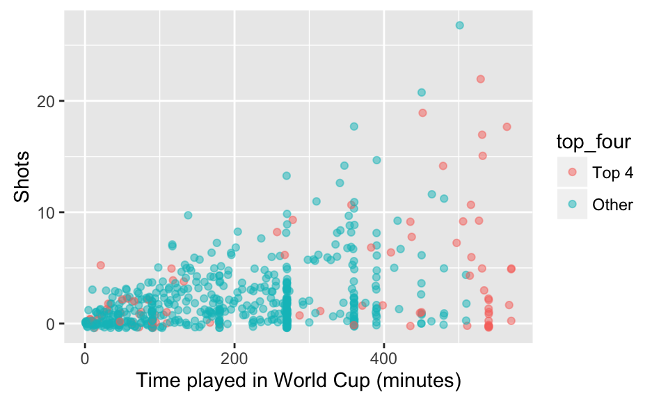

```r
ggplot(worldcup, aes(x = Time, y = Shots,
                     color = top_four)) +
        geom_point(size = 1.5, position = "jitter",
                   alpha = 0.5)  +
        xlab("Time played in World Cup (minutes)")
```

As a note, you can use the `scale_color_discrete()` function to put in a nicer legend title:

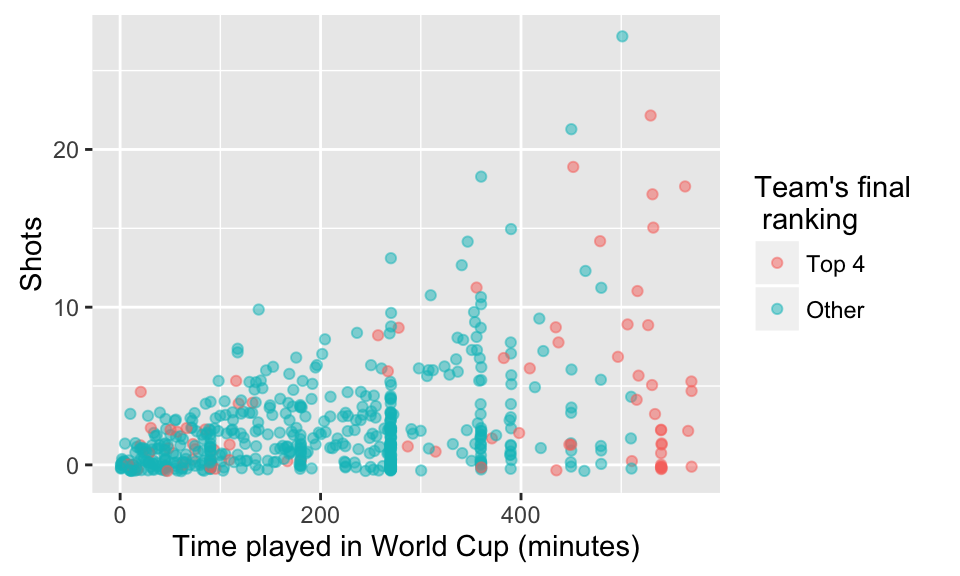

```r
ggplot(worldcup, aes(x = Time, y = Shots,
                     color = top_four)) +
        geom_point(size = 1.5, position = "jitter",
                   alpha = 0.5)  +
        xlab("Time played in World Cup (minutes)") +
        scale_color_discrete(name = "Team's final\n ranking")
```

To create small multiples, use the `facet_grid()` command:

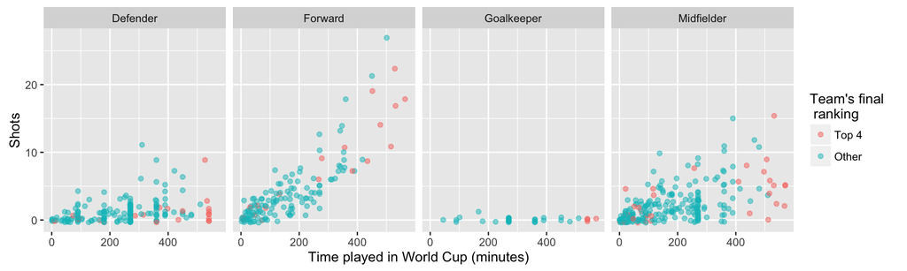

```r
ggplot(worldcup, aes(x = Time, y = Shots,
                     color = top_four)) +
        geom_point(size = 1.5, position = "jitter",
                   alpha = 0.5)  +
        xlab("Time played in World Cup (minutes)") +
        scale_color_discrete(name = "Team's final\n ranking") +
        facet_grid(. ~ Position)
```

To re-order the `Position` column of the dataframe, use the `levels` option of the `factor()` function. This re-sets how R saves the order of the levels of this factor.

```r
worldcup$Position <- factor(worldcup$Position,
                            levels = c("Goalkeeper",
                                       "Defender",
                                       "Midfielder",
                                       "Forward"))
```

Then use the same code from before for your plot:

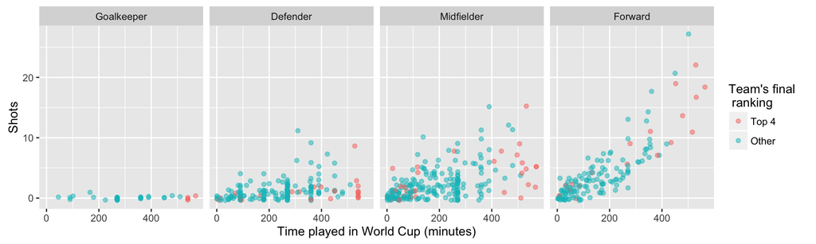

```r
ggplot(worldcup, aes(x = Time, y = Shots,
                     color = top_four)) +
        geom_point(size = 1.5, position = "jitter",
                   alpha = 0.5)  +
        xlab("Time played in World Cup (minutes)") +
        scale_color_discrete(name = "Team's final\n ranking") +
        facet_grid(. ~ Position)
```

You can use the `which.max()` function to index the row of the player with the most shots:

```r
most_shots <- worldcup[which.max(worldcup$Shots), ]
most_shots
```

```
##       Team Position Time Shots Passes Tackles Saves top_four
## Gyan Ghana  Forward  501    27    151       1     0    Other
```

Use `geom_text()` to label his point on the graph with his name. You may need to mess around with some of the options in `geom_text()`, like `size`, `hjust`, and `vjust` (`hjust` and `vjust` say where, in relation to the point location, to put the label), to get something you’re happy with. Also, I pasted on an extra space at the end of the player’s name, to add some “padding” so it wouldn’t be right on top of the point.

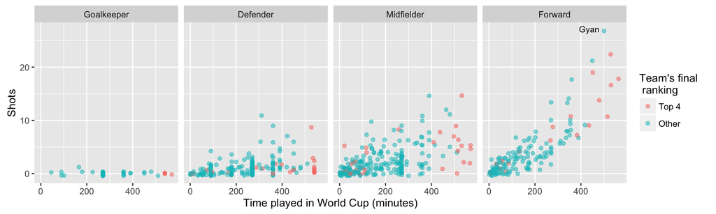

```r
ggplot(worldcup, aes(x = Time, y = Shots,
                     color = top_four)) +
        geom_point(size = 1.5, position = "jitter",
                   alpha = 0.5)  +
        xlab("Time played in World Cup (minutes)") +
        scale_color_discrete(name = "Team's final\n ranking") +
        facet_grid(. ~ Position) +
        geom_text(data = most_shots,
                  label = paste(rownames(most_shots),
                                " "),
                  colour = "black", size = 3,
                  hjust = 1, vjust = 0.4)
```

Try out different themes for the plot. First, I’ll save everything we’ve done so far as the object `shot_plot`, then I’ll try adding different themes:

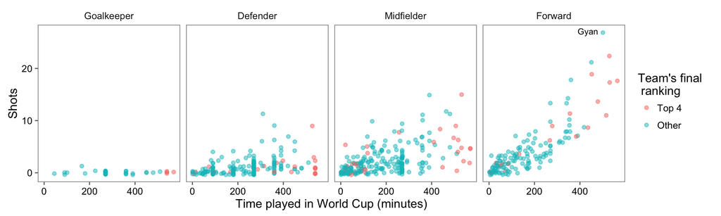

```r
shot_plot <- ggplot(worldcup, aes(x = Time, y = Shots,
                     color = top_four)) +
        geom_point(size = 1.5, position = "jitter",
                   alpha = 0.5)  +
        xlab("Time played in World Cup (minutes)") +
        scale_color_discrete(name = "Team's final\n ranking") +
        facet_grid(. ~ Position) +
        geom_text(data = most_shots,
                  label = paste(rownames(most_shots),
                                " "),
                  colour = "black", size = 3,
                  hjust = 1, vjust = 0.4)

shot_plot + theme_few()
```

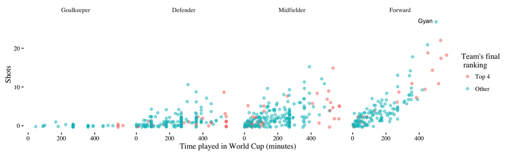

```r
shot_plot + theme_tufte()
```

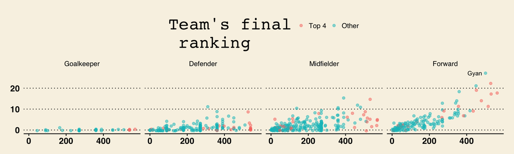

```r
shot_plot + theme_wsj()
```

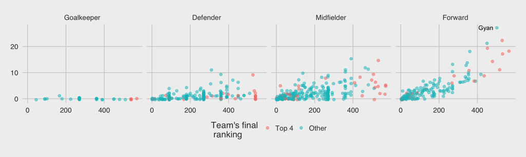

```r
shot_plot + theme_fivethirtyeight()
```

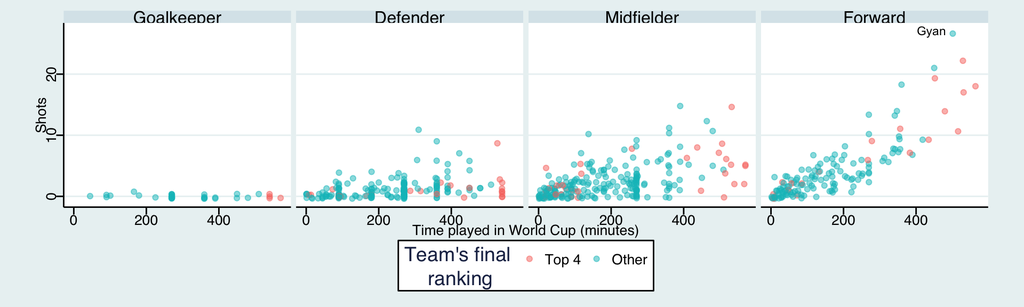

```r
shot_plot + theme_stata()
```

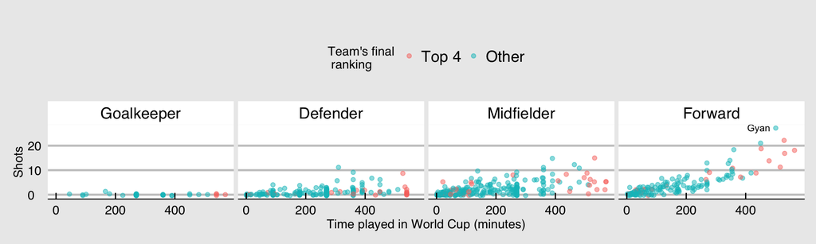

```r
shot_plot + theme_economist_white()
```